# ChristophBlappExercise5

## Question 1

```r
setwd("C:/Users/chris/Desktop")
load("C:/Users/chris/Desktop/countResult1.RData")
load("C:/Users/chris/Desktop/countResult2.RData")
sum(countResult2$counts)-sum(countResult1$counts)
```

```
[1] 181545
```

```r
(sum(countResult2$counts)-sum(countResult1$counts))/sum(countResult2$counts)
```

```
[1] 0.01142662
```

Roughly 1 percent of the alignments was removed when only unambigious ones were included.

## Question 2

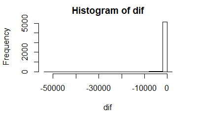

```r
N1.genes <- read.delim("C:/Users/chris/Desktop/RSEM_counts/N1.genes.results")
a<- cbind(countResult1$annotation$GeneID,countResult1$counts[,1]/countResult1$annotation$Length)
a<-data.frame(a)
a<-with(a,a[order(a$X1),])
n<-sum(countResult1$counts[,1]*countResult1$annotation$Length)/sum(countResult1$counts[,1])
a$X2<-as.numeric(as.character(a$X2))
a$X2<-a$X2/sum(countResult1$counts[,1])*100000/n
dif<-a$X2-N1.genes$TPM
dif2<-data.frame(N1.genes$gene_id)
dif2$c<-dif
hist(dif,breaks = 30)
```

That most of the expression differences are around 0 is what I would expect, which gives my confidence in my calculations to get the tpm. Having all values on the same side of Zero also makes sense.

```r
dif2<-dif2[dif2$c<=-10000,]
dif2$N1.genes.gene_id
```

```
 [1] ENSG00000016602 ENSG00000122406 ENSG00000142676 ENSG00000142937 ENSG00000159189 ENSG00000162896 ENSG00000177954
 [8] ENSG00000197273 ENSG00000197747 ENSG00000197956 ENSG00000248527
5228 Levels: ENSG00000000457 ENSG00000000460 ENSG00000000938 ENSG00000000971 ENSG00000001460 ... ENSG00000270172
```

I randomly checked some of these genes and they seem to be ribosomal or ion binding proteins. Counts of such basic workhorses probably arent really the most interesting transcriptome feature, so it seems reasonable to pull them out of the RSEM results.

Now for the fractioned count:

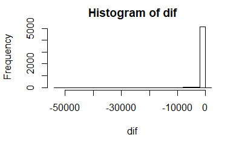

```r
a<- cbind(countResult2$annotation$GeneID,countResult2$counts[,1]/countResult2$annotation$Length)
a<-data.frame(a)
a<-with(a,a[order(a$X1),])
n<-sum(countResult2$counts[,1]*countResult2$annotation$Length)/sum(countResult2$counts[,1])
a$X2<-as.numeric(as.character(a$X2))
a$X2<-a$X2/sum(countResult2$counts[,1])*100000/n
dif<-a$X2-N1.genes$TPM
dif3<-data.frame(N1.genes$gene_id)
dif3$c<-dif
hist(dif,breaks = 30)
```

```r
dif3<-dif3[dif3$c<=-10000,]
dif3$N1.genes.gene_id
```

```
 [1] ENSG00000016602 ENSG00000122406 ENSG00000142676 ENSG00000142937 ENSG00000159189 ENSG00000162896 ENSG00000177954
 [8] ENSG00000197273 ENSG00000197747 ENSG00000197956 ENSG00000248527
5228 Levels: ENSG00000000457 ENSG00000000460 ENSG00000000938 ENSG00000000971 ENSG00000001460 ... ENSG00000270172
```

```r
all.equal(dif2,dif3)
```

```
[1] TRUE
```

No change here. I am a bit surprised actually given how many alignments there should be for rRNA. I guess having only the first chromosome is the cause for this oddity.

## Question 3

```r
c(sum(N1.genes$posterior_mean_count),sum(countResult1$counts[,1]),sum(countResult2$counts[,1]))
```

```
[1] 2410621 2607098 2629480
```

## Question 4

```r
da<-files[[1]]$TPM
da<-cbind(da,files[[3]]$TPM)
da<-cbind(da,files[[5]]$TPM)
da<-cbind(da,files[[7]]$TPM)
da<-cbind(da,files[[9]]$TPM)
da<-cbind(da,files[[11]]$TPM)
cor(da)
```

```
          da
da 1.0000000 0.9045258 0.9221463 0.5763918 0.5878222 0.6092827
   0.9045258 1.0000000 0.9669626 0.6525577 0.6863969 0.6835707
   0.9221463 0.9669626 1.0000000 0.6320960 0.6670324 0.6621788
   0.5763918 0.6525577 0.6320960 1.0000000 0.9468087 0.8570974
   0.5878222 0.6863969 0.6670324 0.9468087 1.0000000 0.9104611
   0.6092827 0.6835707 0.6621788 0.8570974 0.9104611 1.0000000
```

These are the genes. The three treatments and controlls correlate stronger within theri group than with the other group

```r
da2<-files[[2]]$TPM
da2<-cbind(da2,files[[4]]$TPM)
da2<-cbind(da2,files[[6]]$TPM)
da2<-cbind(da2,files[[8]]$TPM)
da2<-cbind(da2,files[[10]]$TPM)
da2<-cbind(da2,files[[12]]$TPM)
cor(da2)
```

```
          da2
da2 1.0000000 0.8891987 0.9076054 0.5559302 0.5743589 0.5631869
    0.8891987 1.0000000 0.9600529 0.6433497 0.6790368 0.6391144
    0.9076054 0.9600529 1.0000000 0.6206674 0.6591583 0.6153022
    0.5559302 0.6433497 0.6206674 1.0000000 0.9419974 0.8405698
    0.5743589 0.6790368 0.6591583 0.9419974 1.0000000 0.8952823
    0.5631869 0.6391144 0.6153022 0.8405698 0.8952823 1.0000000
```

And these are the isoforms. They look similar, but lets take a closer look.

```r
cor(da)-cor(da2)
```

```
           da
da 0.00000000 0.015327032 0.014540902 0.020461614 0.013463319 0.04609579
   0.01532703 0.000000000 0.006909621 0.009207994 0.007360071 0.04445631
   0.01454090 0.006909621 0.000000000 0.011428577 0.007874047 0.04687652
   0.02046161 0.009207994 0.011428577 0.000000000 0.004811310 0.01652758
   0.01346332 0.007360071 0.007874047 0.004811310 0.000000000 0.01517876
   0.04609579 0.044456308 0.046876524 0.016527578 0.015178761 0.00000000
```

T3 seems to shown a bigger correlation difference btween gens and iso with the opposite group than any other combination , but otherwise nothing stands out.